# Math 611 HW10

Jeff Gould

11/3/2020

```r
SampleCasino <- function(bigT){

  X_t <- c("Fair", rep(NA, bigT))

  for (j in 2:(bigT+1)) {
    if(X_t[j-1] == "Fair"){
      X_t[j] = sample(c("Fair", "Cheat"), 1, prob = c(0.95, 0.05))
    }else{
      X_t[j] = sample(c("Fair", "Cheat"), 1, prob = c(0.05, 0.95))
    }

  }

  Y_t <- sapply(X_t, function(x){
    if(x == "Fair"){
      return(sample(1:6, 1))
    }else{
      return(sample(1:6, 1, prob = c(49/250, 49/250, 49/250, 49/250, 49/250, 1/50)))
    }
  })

  return(data.frame(t = c(0:bigT),
                    X = X_t,
                    Y = Y_t))

}

set.seed(1234)
testSample <- SampleCasino(200)
```

### a)

```r
Forward <- function(Y, theta){

  M <- theta[["M"]]
  G <- theta[["G"]]
  pi <- theta[["pi"]]

  alpha <- matrix(NA, nrow = length(Y), ncol = nrow(M))

  C  <- sum(pi * G[,Y[1]])

  alpha[1, ] = G[, Y[1] ] * t(pi) / C

  for (t in 2:nrow(testSample)) {
    c_n <- alpha[t-1, ] %*% M %*% G[,Y[t]]
    C <- c(C, c_n)
    alpha[t, ] <- G[,Y[t]] * (alpha[t-1, ] %*% M) / as.numeric(c_n)
  }

  return(cbind(alpha, C))

}

Backward = function(Y, theta, C){

  M <- theta[["M"]]
  G <- theta[["G"]]
  bigT = length(Y)
  m = nrow(M)
  beta = matrix(1, bigT, m)

  for(t in (bigT-1):1){
    tmp = as.matrix(beta[t+1, ] * G[, Y[t+1]])
    beta[t, ] = t(M %*% tmp) / C[t+1]
  }
  return(beta)
}

ForwardBackward <- function(Y, theta){

  alpha <- Forward(Y = Y, theta = theta)
  C <- alpha[,3]
  alpha = alpha[,1:2]
  beta <- Backward(Y = Y, theta = theta, C = C)

  return(alpha * beta)

}
```

```r
update <- function(Y, Z){
  N <- length(Y)

  N1 <- sum(Z[-N] == 0) ## The number of times the hidden state is in state 1, less the last step
  N2 <- sum(Z[-N] == 1) ## The number of times the hidden state is in state 2, less the last step

  M11 <- 0
  M12 <- 0
  M22 <- 0
  M21 <- 0


  for (i in 1:(length(Z)-1)) { ## Calculate the number of times the hidden state is in state 1 and stays in state 1
    M11 <- M11 + (Z[i] == 0 & Z[i+1] == 0)
  }

  for (i in 1:(length(Z)-1)) { ## Calculate the number of times the hidden state is in state 1 and moves to state 2
    M12 <- M12 + (Z[i] == 0 & Z[i+1] == 1)
  }

  for (i in 1:(length(Z)-1)) { ## Calculate the number of times the hidden state is in state 2 and stays in state 2
    M22 <- M22 + (Z[i] == 1 & Z[i+1] == 1)
  }

  for (i in 1:(length(Z)-1)) { ## Calculate the number of times the hidden state is in state 2 and moves to state 1
    M21 <- M21 + (Z[i] == 1 & Z[i+1] == 0)
  }


  M11 <- M11 / N1 ## Divide all to get transition probabilites
  M12 <- M12 / N1
  M22 <- M22 / N2
  M21 <- M21 / N2

  M <- matrix(c(M11, M12,
                M21, M22), byrow = T, nrow = 2)

  Y0 <- Y[Z==0] ## Y for hidden state is fair
  Y1 <- Y[Z==1] ## Y for hidden state is cheating

  g0 <- sapply(1:6, function(x){mean(Y0==x)})  ## get probabilites for each state
  g1 <- sapply(1:6, function(x){mean(Y1==x)})

  #g0 <- (g0 + 0.02) / sum(g0 + 0.02)
  #g1 <- (g1 + 0.02) / sum(g1 + 0.02)

  # g0 <- g0  / sum(g0)
  # g1 <- (g1) / sum(g1)

  G <- matrix(c(g0, g1), nrow = 2, byrow = T)

  pi <- matrix(data = c(Z[1] == 0, Z[1] == 1), nrow = 2) %>% as.numeric()

  theta <- list(M = M,
                G = G,
                pi = pi)
  return(theta)

}



HardEM <- function(Y, starting_Z = NULL, max_iter = 100){
  iter <- 0

  if(is.null(starting_Z)){
    Z = sample(x = c(0,1), size = length(Y), replace = T)
  }else{
    Z <- starting_Z
  }

  while(iter < max_iter){

    theta <- update(Y = Y, Z = Z)

    Z <- ForwardBackward(Y = Y, theta = theta)
    Z <- round(Z)[,2]

    iter <- iter + 1
  }

  return(list(
    theta = theta,
    Z = Z
  ))



}

Y <- testSample$Y

set.seed(123)
init_Z <- as.numeric(testSample$X == "Cheat")
t <- seq(1,201,20)
init_Z[t] = (init_Z[t] + 1) %% 2

test <- HardEM(Y = Y, starting_Z = init_Z, max_iter = 50)
test$theta
```

```
## $M
##            [,1]       [,2]
## [1,] 0.92207792 0.07792208
## [2,] 0.04878049 0.95121951
##
## $G
##            [,1]      [,2]      [,3]      [,4]      [,5]      [,6]
## [1,] 0.07792208 0.1558442 0.2077922 0.1168831 0.2207792 0.2207792
## [2,] 0.30645161 0.1774194 0.1774194 0.2096774 0.1290323 0.0000000
##
## $pi
## [1] 0 1
```

### b)

```r
### Initialize theta parameters

M <- matrix(c(0.85, 0.15,
              0.15, 0.85), nrow = 2, byrow = T)
pi <- matrix(c(0.8, 0.2), nrow = 2)
set.seed(1)
g1 <- runif(6)
g2 <- runif(6)

G <- matrix(c((g1 + 1)/sum(g1 + 1), (g2 + 0.05) / sum(g2 + 0.05)), nrow = 2, byrow = T)

init_theta <- list(
  M = M,
  pi = pi,
  G = G
)


updateSoft <- function(Y, Z, theta){

  M_prime <- theta$M
  G_prime <- theta$G
  pi_prime <- theta$pi

  N <- length(Y) - 1

  alpha <- Forward(Y, theta) ## get the forward/backward probabilities
  beta <- Backward(Y, theta, alpha[,3])
  alpha <- alpha[,1:2]

  psi11 <- rep(0, N)

  for (t in 1:N) { ## create psi vector for in state 1 and stays in state 1
    psi11[t] <- as.numeric(alpha[t, 1] * beta[t+1, 1] * M[1,1] * G_prime[1 ,Y[t+1]])
  }

  psi12 <- rep(0, N)

  for (t in 1:N) { ## create psi vector for in state 1 and moves to state 2
    psi12[t] <- as.numeric(alpha[t, 1] * beta[t+1, 1] * M[1,2] * G_prime[2,Y[t+1]])
  }

  M11 <- sum(psi11) / sum(psi11, psi12)  ## normalize
  M12 <- sum(psi12) / sum(psi11, psi12)


  psi22 <- rep(0, N)

  for (t in 1:N) { ## create psi vector for in state 2 and stays in state 2
    psi22[t] <- as.numeric(alpha[t, 2] * beta[t+1, 2] * M[2,2] *G_prime[2,Y[t+1]])
  }

  psi21 <- rep(0, N)

  for (t in 1:N) {  ## create psi vector for in state 2 and moves to state 1
    psi21[t] <- as.numeric(alpha[t, 2] * beta[t+1, 1] * M[2,1] *  G_prime[1,Y[t+1]])
  }

  M21 <- sum(psi21) / sum(psi21, psi22)
  M22 <- sum(psi22) / sum(psi21, psi22)

  M_update <- matrix(c(M11, M12,
                       M21, M22), byrow = T, nrow = 2)

  g1 <- sapply(1:6, function(x){
    sum(Z[,1] * (Y == x)) / (sum(Z[,1]))
  })

  g2 <- sapply(1:6, function(x){
    sum(Z[,2] * (Y == x)) / (sum(Z[,2]))
  })

  G_update <- matrix(c(g1, g2), byrow = T, nrow = 2)

  pi_update <- matrix(Z[1,], nrow = 2)

  theta_new <- list(M = M_update,
                    G = G_update,
                    pi = pi_update)

  return(theta_new)

}





softEM <- function(Y, start_theta, max_iter){

  iter <- 0
  theta <- start_theta
  while(iter < max_iter){
    Z <- ForwardBackward(Y = Y, theta = theta)

    theta <- updateSoft(Y, Z, theta = theta)

    iter <- iter + 1

  }

  return(list(Z = Z,
              theta = theta))



}

testB <- softEM(Y = testSample$Y, start_theta = init_theta, max_iter = 100)

testB$theta
```

```
## $M
##           [,1]      [,2]
## [1,] 0.8369945 0.1630055
## [2,] 0.1264051 0.8735949
##
## $G
##           [,1]      [,2]      [,3]      [,4]      [,5]         [,6]
## [1,] 0.1091667 0.2023434 0.1686101 0.1224041 0.2014999 1.959759e-01
## [2,] 0.3022223 0.1439561 0.2045769 0.2134007 0.1358441 5.152403e-09
##
## $pi
##              [,1]
## [1,] 2.804385e-18
## [2,] 1.000000e+00
```

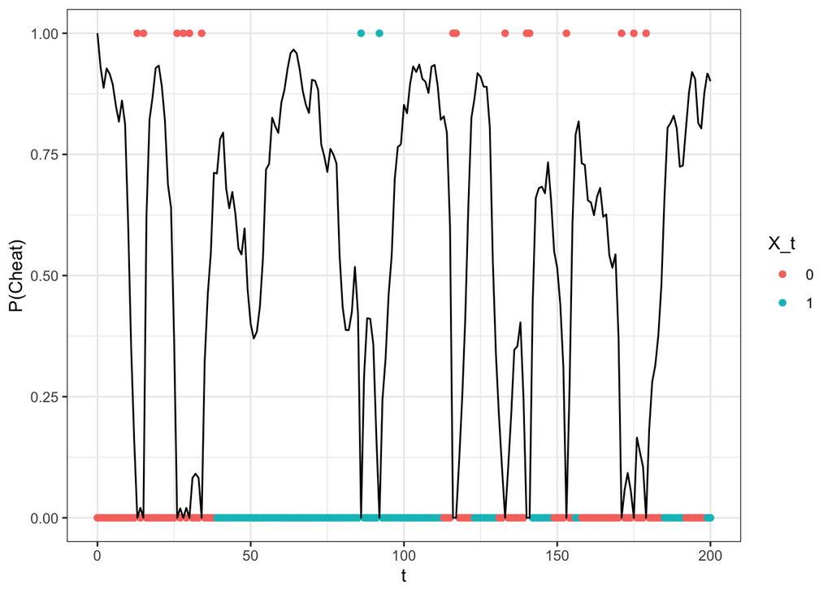

```r
results <- data.frame(p_cheating = testB$Z[,2],
                      Y_t = testSample$Y,
                      X_t = as.numeric(testSample$X == "Cheat"),
                      t = seq(0, 200))

results %>%
  mutate(is_6 = ifelse(Y_t == 6, 1, 0),
         X_t = as.factor(X_t)) %>%
  ggplot(aes(x = t)) +
  geom_point(aes(y = is_6, color = X_t)) +
  theme_bw() +
  geom_line(aes(y =  p_cheating)) +
  labs( y = "P(Cheat)")
```

## 2

### a) To get a feel for the sample paths of Brownian motion, generate a sample of $B(t)$ for i) $\sigma^2 = 1$ and ii) $\sigma^2=10$ up to time $t=10$ using a grid of width $.01$.

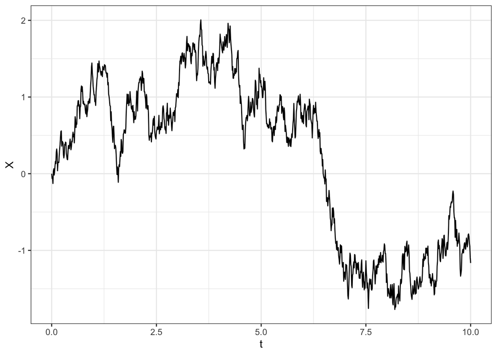

```r
BrownianMotion <- function(t, delta_t, sigma2){

  intervals <- t / delta_t

  X <- c(0, rnorm(n = intervals, sd = sqrt(sigma2 * delta_t)))

  X <- data.frame(X = cumsum(X),
                  t = seq(0, t, delta_t))

  return(X)



}

set.seed(1)
BM1 <- BrownianMotion(t = 10, delta_t = 0.01, sigma2 = 1)

ggplot(BM1, aes(x = t, y = X)) +
  geom_line() +
  theme_bw()
```

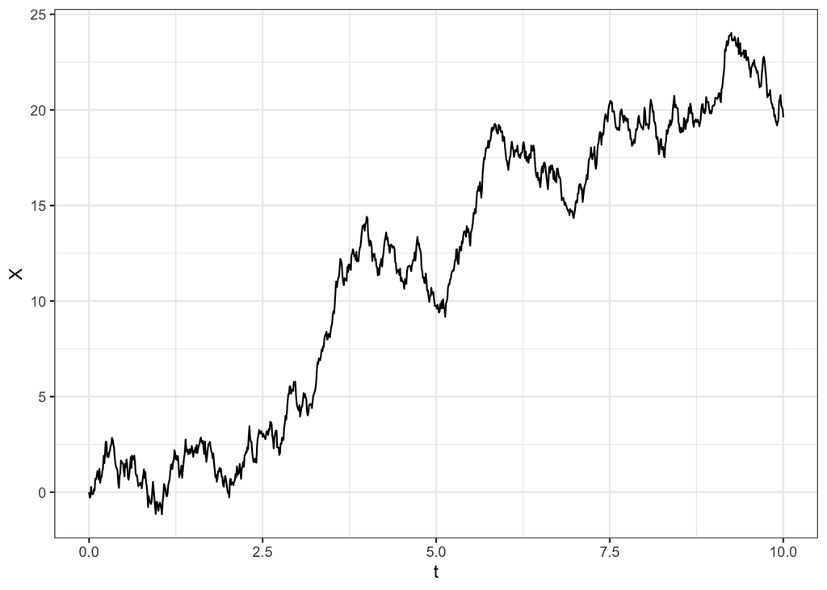

```r
set.seed(2)
BM2 <- BrownianMotion(t = 10, delta_t = 0.01, sigma2 = 10)


ggplot(BM2, aes(x = t, y = X)) +
  geom_line() +
  theme_bw()
```

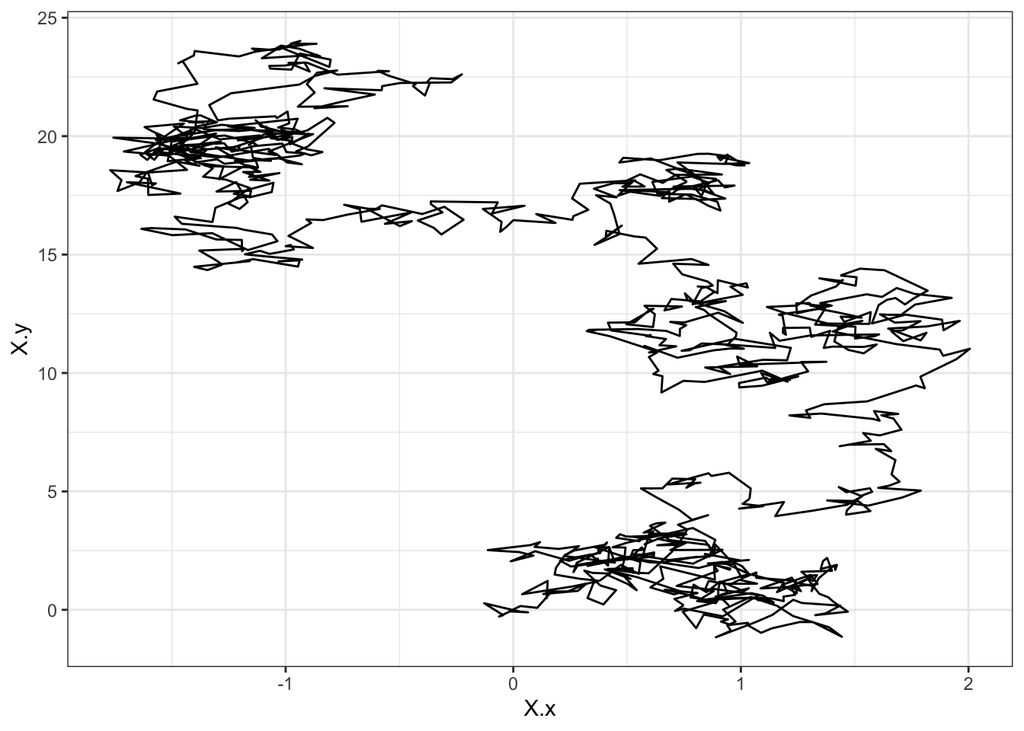

```r
left_join(BM1, BM2, by = c("t" = "t")) %>%
  ggplot(aes(x = X.x, y = X.y)) +
  geom_path() +
  theme_bw()
```

### b) Let $t_1 < t_2 < t_3$.

- Calculate $E[B(t_1)B(t_2)]$.

$B(t_2) = B(t_1) + \mathcal{N}(0, (t_2 - t_1)\sigma^2)$

$E[B(t_1)B(t_2)] = E[B(t_1)(B(t_1) + \mathcal{N}(0, (t_2 - t_1)\sigma^2))] = E[B(t_1)B(t_1)] + E[B(t_1)\mathcal{N}(0, (t_2 - t_1)\sigma^2))] = E[B(t_1)^2]$

$E[B(t_1)^2] = Var[B(t_1)^2] + E[B(t_1)]^2 = t_1\sigma^2$

- Calculate $E[B(t_1)B(t_2)B(t_3)]$.

$B(t_2) = B(t_1) + [B(t_2)- B(t_1)]$

$B(t_3) = B(t_2) + [B(t_3) - B(t_2)] = B(t_1) + [B(t_2)- B(t_1)] + [B(t_3) - B(t_2)]$

$E[B(t_1)B(t_2)B(t_3)] = E\left[B(t_1)[B(t_1) + [B(t_2)- B(t_1)]][B(t_1) + [B(t_2)- B(t_1)] + [B(t_3) - B(t_2)]] \right]$

Let $x_1 = B(t_1)$, $x_2 = B(t_2) - B(t_1)$, and $x_3 = B(t_3) - B(t_2)$

Then $E[x_1] = E[x_2] = E[x_3] = 0$, and all are independent

$E[B(t_1)B(t_2)B(t_3)] = E\left[B(t_1)[B(t_1) + [B(t_2)- B(t_1)]][B(t_1) + [B(t_2)- B(t_1)] + [B(t_3) - B(t_2)]] \right] =$

$E[x_1(x_1 + x_2)(x_1 + x_2 + x_3)] = E[x_1^3 + 2x_1^2x_2 + x_1x_2^2 + x_1^3x_3 + x_1x_2x_3] = E[x_1^3] + E[2x_1^2x_2] + E[x_1x_2^2] + E[x_1^3x_3] + E[x_1x_2x_3] = E[x_1^3] = E[B(t_1)^3] =0$

Where $E[B(t_1)^3] =0$ follows from the third moment of a normal r.v. with mean 0 is 0.